# Brazilian Football Broadcasting Rights - IBBA Notes

# Brazilian Football Broadcasting Rights - IBBA Notes

May 15, 2026

**Section 1 - The Brazilian Football Broadcasting Rights Market**

- Pillar #1 - From Monopoly to Fragmentation (1987-2021)
- Pillar #2 - Libra and LFU: The Two Blocs
- Pillar #3 - Toward a Single League
- Pillar #4 - Commercial Architecture: Contracts and Distribution (2025-2029)

**Section 2 - LiveMode: A Case Study in Sports Rights Distribution**

- Pillar #1 - Origin and Business Model
- Pillar #2 - CazéTV
- Pillar #3 - Institutional Capital and Shareholders
- Pillar #4 - Rights Portfolio and International Ambition

**Section 3 - Sizing the Brazilian Sports Rights Opportunity**

- Pillar #1 - The 2025 Baseline and Audience Trajectory
- Pillar #2 - Brazil vs Global Comparables
- Pillar #3 - Growth Vectors and Risks to 2029
- Pillar #4 - Forward Outlook: Three Scenarios

**Sources - Compiled by Section and Pillar**

# SECTION 1 - The Brazilian Football Broadcasting Rights Market

**Brazilian football is one of the most globally followed sports leagues, yet its broadcasting rights market has long operated under remarkably closed conditions.** Three decades of stable economics are now being rewritten simultaneously by regulatory unbundling, institutional capital and digital disruption. The market looks more mid-inflection than mid-cycle, a meaningfully different framing for investors used to incremental change in sports rights.

**The story moves from monopoly to fragmentation, and now potentially back to consolidation on meaningfully different terms.** It begins in 1987 with the Clube dos 13 and the unravelling that culminated in the 2021 Lei do Mandante; runs through the two competing blocs that emerged in 2022, Libra and LFU, and the CBF-mediated unification now underway; and ends with the 2025-2029 contract architecture across five broadcasters and the rules governing revenue distribution. Even so, the rewrite is unfinished, and the 2029 renegotiation looks set to be the key test.

# Pillar #1 - From Monopoly to Fragmentation (1987-2021)

**Brazilian football is a national passion, but as a business it has long been one of the most concentrated TV markets in the world.** For more than three decades, the rights to broadcast Brazil’s top league, the Brasileirão (Série A), were sold collectively by a single bloc of clubs and bought almost exclusively by Globo, Brazil’s largest media group. To understand why the market is changing now, we start with how that closed system was built, and how regulation pulled it apart.

### Clube dos 13 and the collective era

**The collective era began on 11 July 1987, when Brazil’s thirteen leading clubs formed a negotiating cartel called the Clube dos 13.** Formally the União dos Grandes Clubes do Futebol Brasileiro, the bloc replaced individual negotiation with a single collective package against the dominant network, and the strategy worked. The first multi-year deal with Globo, signed in 1997, covered the 1997-1999 cycle; by the 2009-2011 cycle, the contract had grown to ~BRL 1.4bn, the high-water mark of the clubs’ collective pricing power. One reading is that the C13 era succeeded not because Brazilian football was uniquely concentrated, but because the legal regime made unilateral selling impractical, the structural feature that would later become the very lever for fragmentation.

### The unravelling and the Globo monopsony (2011-2020)

**The model began to break down in the 2011-2012 cycle.** Brazil’s biggest clubs, Flamengo, Vasco, Fluminense, Botafogo, Santos and Palmeiras, concluded they could extract better terms by negotiating directly with Globo rather than splitting the pot equally with smaller clubs, and departed one by one. Without its anchor members, the cartel lost leverage and was effectively dissolved over the next decade (surviving only formally, for residual legal matters). The exits were a classic prisoner’s dilemma: rational individually but value-destroying for the group, the same dynamic that now threatens both Libra and LFU at the margins, and why unification matters disproportionately for smaller clubs.

**The vacuum produced an unwritten arrangement that held for roughly ten years: Globo as the only meaningful buyer across every window.** Globo controlled i) free-to-air broadcast TV (the open Globo channel); ii) pay-TV (SporTV); and iii) pay-per-view (Premiere, its premium package for individual matches). No other buyer had the scale to challenge it, and pricing power sat firmly with the incumbent. This is the mental model that still anchors many investors’ view of Brazilian football economics today, and the structural backdrop that regulatory reform would disrupt.

### MP 984/2020 - the failed first attempt

**Globo’s dominance lasted because of legal architecture, not just commercial scale.** Under Brazilian law, arena rights (direitos de arena) were jointly held by the home AND visiting club, so any broadcaster had to secure both clubs’ consent, which made fragmented selling impractical and pushed everyone toward negotiating with the bloc and Globo simultaneously. Two regulatory changes between 2020 and 2021 broke this structure.

**The first came in June 2020, when the Bolsonaro government issued an emergency decree, MP 984, transferring arena rights exclusively to the home club**, amending the Lei Pelé (1998) and the Statute of the Fan (2003). Brazilian emergency decrees, however, lapse if not voted into law within 120 days, and MP 984 expired without a vote, reverting to the prior regime. Still, it established the legal principle and built political momentum for the definitive legislation a year later. The failure appears to have been about timing rather than substance: the Bolsonaro-Congress relationship in mid-2020 was strained, and arena rights was not the priority needed to clear the window.

### Law 14,205/2021 (Lei do Mandante) - the definitive change

**The definitive change came in September 2021, when Congress passed Law 14,205, the Lei do Mandante (“Home Club Law”).** Arena rights were transferred permanently to the home club for every match, with one carve-out: athletes (including reserves) receive 5% of arena rights revenue, distributed equally. From that moment, broadcasters needed to negotiate with only one club per match, and clubs gained the unilateral right to sell their games alone or in self-organized groups. In other words, the collective monopoly was no longer a legal necessity; it became a voluntary choice.

**The structural implication the market is still digesting: the new rule enabled bloc formation AND bloc fragmentation simultaneously.** Clubs can now exit any bloc and sell elsewhere, the proximate reason Libra and LFU have seen departures since 2024. The path to stability plausibly runs through unification rather than competition: bloc-vs-bloc dynamics appear to carry a built-in centrifugal force the law itself created.

**The 2025 Brasileirão was the first championship played fully under the new regime, and the first to show the change materializing in contract architecture.** With home clubs holding unilateral selling rights, the new blocs could aggregate and negotiate competing packages, attracting Amazon, Record (a free-to-air TV network) and CazéTV/YouTube alongside the incumbent Globo group. The read-through: the 2025 contract architecture is the first observable output of the legal change, not its cause.

# Pillar #2 - Libra and LFU: The Two Blocs

**Once the law changed in 2021, clubs faced a structural choice: sell rights individually, or organize into new collective blocs.** Two competing leagues emerged in rapid succession during 2022, on fundamentally different philosophies. Libra came first, built around concentration and the financial weight of Brazil’s biggest clubs; LFU came second, built around egalitarian distribution and broader inclusion. The two spent 2022-2025 in open competition for clubs and rights deals, and are now negotiating to merge.

### Why two blocs emerged

**The vacuum left by the Clube dos 13 needed a successor, and the Lei do Mandante created the urgency.** By early 2022, two camps had formed. The first, led by Flamengo, Corinthians and other heavyweights, wanted a Premier League-style model rewarding brand size and historical performance. The second, mostly mid-tier and rising clubs, wanted a flatter model protecting clubs outside the traditional “big four”. Both attempted a unified solution through late 2021 and early 2022, but the difference in distribution philosophy proved irreconcilable. By May 2022, the two sides had separated.

### Libra - concentration

**Libra (Liga do Futebol Brasileiro) was founded on 3 May 2022 by eight clubs:** Corinthians, Cruzeiro, Flamengo, Palmeiras, Ponte Preta, Red Bull Bragantino, São Paulo and Santos. Modelled explicitly on the Premier League, it aimed to distribute TV revenues “more efficiently”, meaning more weight to commercial size, and peaked at 18 clubs through 2022-2024. Since then, the bloc has seen successive departures. Of the original 8 founders, only Flamengo, Red Bull Bragantino, São Paulo and Santos remain; new members are Bahia, Grêmio, Vitória, Remo, Paysandu, Volta Redonda, ABC, Guarani, Sampaio Corrêa and Brusque. For the 2026 Série A, Libra is expected to field 10 clubs, down from 12 in 2025 and well below the original 18-club ambition. The departures arguably reflect a Premier League aspiration meeting Brazilian reality: the top clubs are concentrated enough to lead the audience component every year, so smaller Libra members tend to receive less than in a flatter bloc.

### Diverging trajectories, side by side

**From their parallel May/June 2022 birth, the two blocs took diverging paths:** LFU consistently added members and economic weight, while Libra ceded ground in every major realignment since 2023.

**LFU/FFU’s strengthening trajectory:**

- **Jun/2022**, Constitution with 25 clubs across Séries A, B and C
- **Jul/2023**, Closing of LFU rebrand with 26 clubs (formation of Grupo União with Botafogo, Cruzeiro, Vasco, Coritiba)
- **Nov/2023**, Agreement with Paulistas clubs maintains 26-club count
- **May/2024**, Closing of Série A rights sale: BRL 1.1bn disbursed by investors (Serengeti, Life Capital Partners, XP); 31 clubs
- **Jul/2024**, Agreement with Corinthians (migrating from Libra); 32 clubs
- **Jan/2025**, LFU reaches 80% of Série B clubs; 33 clubs total
- **Sep/2025**, Agreement with Vitória; LFU reaches 70% of combined Séries A+B clubs (34 clubs), with economic position +50% versus 2024

**Libra’s declining trajectory:**

LFU vs Libra: clubs in Série A per year (avg LFU 12.6 vs Libra 7.4)

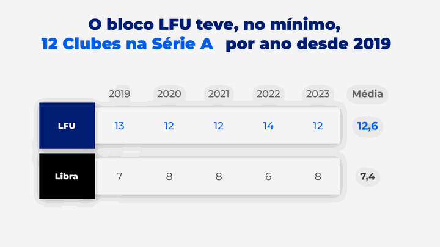

Source: LFF / MATERIAL LIGA, p.20

### Institutional capital and cross-holdings

LFU rights transaction: terms and investors (BRL 1.3bn, 10%, 50 years)

[figure not shown]

Source: LFF / MATERIAL LIGA, p.11

**The deal was benchmarked against recent private-equity investments in European leagues.** Internal LFU materials position the transaction against two precedents on similar 50-year horizons: CVC’s 2021 investment in La Liga, at roughly 12.2x the league’s commercial revenue, and CVC’s 2022 investment in Ligue 1, at roughly 14.1x. LFU’s own deal, at around 11.5x its 2023 commercial rights base, sits at or slightly below that range. The read-through is that LFU was priced as an institutional-grade sports-rights vehicle rather than a one-off private deal, and the multiple looks defensible if the unified-league hypothesis materializes.

PE deal comparables: LFU vs La Liga vs Ligue 1 (multiple of 2023 revenue)

[figure not shown]

Source: LFF / MATERIAL LIGA, p.12

### Mubadala-Libra discussions

**Libra has its own institutional capital story, but it remains unfinished.** Mubadala, the Abu Dhabi sovereign wealth fund, has been in extended discussions with Libra through 2024-2025. The original proposal envisioned a BRL 4bn injection conditional on at least 18-team participation; the reformulated version scaled back to a 50/50 commercialization agency (Libra clubs and Mubadala) with a BRL 1.4bn guaranteed annual revenue floor, contingent on at least 9 Libra clubs in Série A, holding exclusive selling rights for 25 years (2025-2049). For now, the proposal remains under discussion with no binding commitment. The original thesis appears challenged at current terms: it was conceived for an 18-team Libra, now operating at 10 with further departures possible. Mubadala could plausibly re-enter at the unified-league level instead, a structurally different transaction.

### Realignments and the Flamengo dispute

**Bloc composition shifted significantly across 2024-2025.** Corinthians migrated from Libra to LFU in late 2024; Atlético-MG followed, with Neofeed reporting the move could catalyze further departures. The most consequential event came in late 2025, when Flamengo entered a public dispute with the rest of Libra. Under new president “Bap” (Luiz Eduardo Baptista), Flamengo, the largest club in Brazil by fan base and revenue, argued that Libra’s audience-calculation methodology lacked technical clarity and unfairly underweighted its share. The settlement granted Flamengo an incremental BRL 150mn over four years on top of standard distribution, in annual instalments of BRL 37.5mn with inflation indexation from 2027. Palmeiras announced its exit immediately afterwards, citing “selfish attitudes” from remaining members. These realignments are not over: multiple sources expect further migrations when the current cycle ends in 2029.

### CADE oversight

**In late 2025, CADE (Brazil’s competition authority) cleared both agreements but imposed conditions.** Libra paid a BRL 559k fine for “gun-jumping”, failing to notify CADE before consolidating commercial rights, and CADE barred both blocs from adding clubs during an investigation into potential anticompetitive behavior. This is now part of the structural backdrop: it caps bloc growth short-term, and the investigation’s outcome should shape the regulatory perimeter of the unified league. A plausible base case is that CADE eventually approves the unified league with binding conditions on minority-club protections and revenue-distribution caps. Timing stands out as the principal risk: if CADE acts before unification concludes, it could disrupt the negotiation by setting external boundaries one of the blocs would otherwise resist.

### The SAF revolution - investor-led clubs reshape bloc dynamics

**Parallel to the Lei do Mandante, Congress passed Law 14,193/2021, the “Lei da SAF”, allowing clubs to convert from non-profit associations into corporations (Sociedade Anônima do Futebol).** Clubs could now i) issue shares; ii) attract institutional capital; and iii) operate under corporate rather than association law. As of 2026, 42 Brazilian clubs have converted to SAFs, with investors ranging from family offices to global private equity. The implication for bloc dynamics is direct: SAFs answer to investors who care about commercial maximization rather than legacy loyalty to one bloc.

The most consequential transactions:

- **Red Bull Bragantino (2019), Red Bull GmbH.** The earliest precursor, predating the Lei da SAF by two years; structured under earlier corporate frameworks but SAF-like in substance: single corporate owner, professional management, full integration with Red Bull’s global portfolio (Salzburg, Leipzig, New York). Widely cited as the proof-of-concept for Law 14,193/2021. One of the four original Libra founders still in the bloc.
- **Botafogo SAF (2022), John Textor / Eagle Football.** US investor paid a minimum of BRL 400mn for control; Textor also owns Lyon, Crystal Palace (until 2024) and Molenbeek. Botafogo’s move from Libra to LFU is widely read as investor-driven.
- **Cruzeiro SAF (2021), Ronaldo → Pedro Lourenço (2024).** Ronaldo Nazário took control for ~BRL 400mn; sold to Pedro Lourenço (Supermercados BH) in 2024 amid debt rebuild. In LFU.
- **Vasco SAF (2022), 777 Partners.** BRL 1.4bn deal that became the cautionary tale of the era. 777 unwound globally in 2024 (multiple US lawsuits, parallel difficulties at other 777 clubs); Brazilian courts suspended its rights at Vasco, which temporarily reverted to associative control while a successor is sought.
- **Bahia SAF (2023), City Football Group.** Manchester City’s parent group, the only Brazilian SAF backed by an established global football operator.
- **Atlético-MG SAF (2024).** Concentrated local ownership rather than external PE; ended 2025 with rising debt despite the new structure.

**The SAF wave matters to the broadcasting story for three reasons:** i) it brought professional investors into bloc-level negotiations: the GA-LFU-LiveMode triangle only makes sense where clubs are corporatized and can accept private capital; ii) it accelerated bloc fragmentation, because SAF investors optimize their own economics over associative loyalties, explaining why migrations have clustered among recently-converted SAFs (Botafogo, Cruzeiro, Atlético-MG); and iii) it introduced execution risk: the 777 unwinding at Vasco, recurring debt at Atlético-MG and Botafogo, and whether Brazilian football can sustain this many institutional investors at once. That said, the wave looks unlikely to reverse: the framework is established, the capital deployed, and the few resisters (notably Flamengo and São Paulo) remain associations more by tradition than strategic preference.

# Pillar #3 - Toward a Single League

**After three decades pulling apart, Brazilian football is now moving the other way, toward a single, unified league.** The reason is simple: by early 2026, neither bloc was winning. Libra had lost about half its members and struggled to attract investors on good terms, while LFU had signed the bigger 2025-2029 deals but realized that fighting bloc-against-bloc was shrinking the pie for everyone. With both sides stuck, a third party stepped in: the CBF (Brazil’s football confederation), under new president Samir Xaud, began mediating. What emerged is a formal, three-part process: a Memorandum of Understanding between the blocs, a CBF-led timeline running through 2026, and a target of one unified league by 2030.

### What the two blocs agreed to (the MOU)

**In late 2025/early 2026, Libra and LFU signed a Memorandum of Understanding, a statement of intent, not yet a binding contract.** It commits them to two things: to sell broadcasting rights together in a future cycle instead of competing for separate deals, and to build a shared rulebook for running Séries A and B (competition format, financial rules, stadium standards, governance). The MOU leaves the exact timeline open (that is being worked out through the CBF), but it settles the direction of travel. Its real significance is what it signals: both blocs have effectively conceded that competing against each other has run its course. The economics now point one way: a single seller facing several buyers is worth more than two blocs underbidding each other, so the question has shifted from whether to unify to how.

### Why the CBF’s role is unusual

**Historically, the CBF and the clubs sat on opposite sides, arguing over money and the calendar.** Under Xaud, that flipped: the CBF is acting as a neutral facilitator, publicly backing an independent league, hosting the talks at its headquarters, and proposing ground rules. The key point is what it is giving up: the CBF has said it will not run the new league day-to-day. That would make Brazil’s top division club-owned and club-managed, like the Premier League or La Liga. For the CBF this is a sensible trade: it sheds the operational headaches and the endless distribution fights while keeping the assets it actually cares about: the national team, its FIFA relationships, and control of the calendar. That willingness to step back is arguably the clearest sign that unification has become the base case rather than just a nice idea.

### The roadmap: 2026 to 2030

**The process took its biggest step on 6 April 2026, when the CBF gathered 38 of the 40 Séries A and B clubs at its Rio headquarters** (only Chapecoense and Mirassol were absent). The meeting set a calendar for the rest of the year: collect proposals from May to July, debate them and put them to a club vote from August to September, then draft the new league’s statute and commercial structure from October to December. The aim is a finished statute by end-2026, with some practical changes (joint marketing, a common rulebook) starting even before the league formally launches.

**That launch is targeted for the start of the 2030 season, right after the current 2025-2029 broadcast contracts expire.** The timing is deliberate: it lets the existing deals run their course first. From 2030, a single league would handle rights sales for both blocs, run the Séries A and B calendar, set common financial and infrastructure rules, and, crucially, negotiate as one counterparty in the next rights cycle.

### What could still go wrong

**Progress is real, but three issues remain open.** The first, and the most serious, is financial fair play: LFU wants strict spending limits, arguing that clubs which overspend distort the competition, while Libra, Flamengo in particular, resists rules that would cap its flexibility. The second is narrower and largely symbolic: whether synthetic pitches should be allowed, with smaller clubs treating them as a cost saver and bigger clubs preferring natural grass. The third is governance: how votes are shared, and whether smaller clubs can be outvoted. The April meeting settled none of these, and they carry into the second half of 2026. Of the three, financial fair play looks the most likely to stall the talks, making the Flamengo-FFP standoff the thing to watch most closely through Q3 2026.

**If the timeline holds, the 2029 renegotiation becomes the first real test of the unified model, and the first time in Brazilian football history that a single seller negotiates against multiple buyers at once.** That is the inflection that anchors our sizing: one league should command more leverage than two competing blocs. The caveat is equally clear: if unification stalls, fragmentation could persist past 2029, and the multi-buyer market built in this cycle could unwind without a stronger seller to hold it together.

# Pillar #4 - Commercial Architecture: Contracts and Distribution (2025-2029)

**The contracts Libra and LFU signed for 2025-2029 are the first concrete output of the new market structure.** Instead of one dominant buyer paying for everything, there are now five distinct buyers acquiring different rights through different channels: broadcast TV, pay-TV, pay-per-view, streaming and digital/YouTube. This pillar maps who paid what to whom, why all major contracts are synchronized to end in 2029, and how each bloc then divides the money, the half of the story that can materially help or hurt clubs, shape competition and prompt the kind of disputes we saw between Flamengo and Libra.

### LFU contracts - the aggregate position

**LFU’s combined contracted revenue for 2025 reaches ~BRL 1.7bn per year across four buyers.** i) Globo pays BRL 850mn per year to broadcast five matches per round of 12 LFU clubs on its main free-to-air channel; ii) Amazon Prime Video pays BRL 265mn in Year 1 (escalating to ~BRL 2bn cumulative over five years) to stream one exclusive match per round; iii) Record (a competing free-to-air network) pays BRL 200mn per year; and iv) CazéTV/YouTube pays BRL 175mn per year for OTT and digital rights (rising to ~BRL 262mn including associated Betano sponsorship). Notably, the Record and CazéTV/YouTube deals were both extended to 2029 in August 2025, synchronizing the LFU stack to a common renegotiation window.

### Libra contracts - the concentrated position

**Libra took the opposite strategy, betting on a single buyer.** It closed an exclusive deal with Globo at BRL 1.3bn per year, reduced to BRL 1.17bn after Corinthians’ migration to LFU, plus a variable component: Libra receives 40% of net Premiere PPV revenue, providing upside tied to premium-package subscriptions each season. The contract spans 2025-2029, aligning with LFU’s window.

### LiveMode as broker

**Three of the four LFU contracts, Amazon, Record and CazéTV/YouTube, were intermediated by LiveMode**, the de facto rights distribution platform for one half of the market. This goes well beyond a traditional rights advisor, especially given that General Atlantic, an LFU investor, also holds a minority stake in LiveMode, creating vertical alignment between league capital, platform and buyers. LiveMode’s broader mandate also covers i) the Paulistão; ii) FIFA tournaments (World Cup, Women’s World Cup, Club World Cup); iii) UEFA competitions (Euro, Europa League); and iv) the Olympic Games.

### Globo’s strategic response - repositioning, not retreat

- **Brasileirão contracts**, Globo retains the largest packages in both Libra (BRL 1.17bn/year) and LFU (BRL 850mn/year), plus Premiere PPV upside via the 40% Libra share.
- **Copa do Brasil**, exclusive until end-2026; the 2027-2030 cycle is in active negotiation, with Globo facing its first credible competition from Disney/ESPN and CazéTV.
- **Estaduais**, Globo dominates regional championships outside São Paulo (Carioca, Mineiro, Cearense, Pernambucano, others). Paulistão is the exception, captured by LiveMode, illustrating what a multi-buyer auction can deliver when the bloc is well-organized.
- **GeTV**, Globo launched a new ad-supported digital sports channel to compete directly with CazéTV: same model (free, ad-monetized), but with Globo’s production infrastructure and rights behind it.
- **Globoplay Premium**, Globo’s streaming tier now carries selected Brasileirão matches, to upsell pay-TV refugees who left Premiere/SporTV.

**The repositioning is consistent with how every legacy incumbent has responded to digital disruption:** i) keep the most valuable rights; ii) monetize across windows (broadcast + pay + PPV + streaming); and iii) launch defensive products where you would otherwise lose share. The risk is concentration in the next cycles: Copa do Brasil 2027 and Brasileirão 2029 should both take place under multi-buyer competition, and Globo’s captured share could compress further. Even so, the opportunity is equally real: Globo still has unmatched production and distribution scale, so it remains the bid floor on most packages even when it does not win them outright.

Paulistão rights packaging: auction packages A-D (free / pay / PPV) and winners

[figure not shown]

Source: LFF / MATERIAL LIGA, p.26

### 2029 - the synchronized renegotiation

**A key feature of the current cycle is that every major contract expires at the end of 2029.** This synchronization was not accidental, both blocs and the broadcasters preferred a common end date to align future negotiations. The implication is that 2029 should be the first fully multi-buyer renegotiation across the entire market simultaneously, and potentially the first conducted by a unified league rather than two competing blocs. This looks like a structural inflection point, with two diverging outcomes: either the new architecture consolidates higher pricing (multiple buyers against a unified seller), or it reverts toward concentration if buyers retrench. We treat this as the anchor of our forward sizing scenarios.

### Libra criteria - 40/30/30

**Libra uses a three-component formula: 40% equal, 30% performance, 30% audience.** The 40% equal share is a “solidarity” component every team receives; the 30% performance share is allocated by final league position; and the 30% audience share by each club’s share of paying Premiere subscribers, a proxy for fan base size. The audience component structurally favors larger fanbases, creating a self-reinforcing concentration effect (more fans → more revenue → better squad → more fans). The distribution base is BRL 1.17bn per year fixed (assuming at least 9 Libra clubs in Série A), plus 40% of net Premiere PPV revenue.

### LFU criteria - 45/30/25

**LFU adopted a modestly flatter formula: 45% equal, 30% performance, 25% audience.** The 5pp lower audience weight versus Libra fits its positioning as the league for clubs that benefit from more equal distribution. In practice, the aggregate difference is meaningful but not huge: a mid-sized club gets a slightly higher share of a slightly bigger pie (LFU’s BRL 1.7bn pool vs Libra’s BRL 1.17bn).

### What the actual distribution looks like

**The framework produces a real-world distribution even more skewed than the 5.7x global ratio suggests.** Galapagos Outfield 2024 data shows actual broadcasting revenue per Série A club in 2024, with Flamengo capturing ~8x the smallest clubs, closer to a 1-club / 19-club asymmetry than a peer-comparable league.

**Top 5 clubs by 2024 broadcasting revenue (BRL mn):**

- Flamengo, **454**
- Corinthians, **295**
- Botafogo, **285**
- Atlético-MG, **248**
- Palmeiras, **244**

**Bottom 5 clubs by 2024 broadcasting revenue (BRL mn):**

- Cuiabá, **56**
- Athletico-PR, **58**
- Atlético-GO, **58**
- Criciúma, **60**
- RB Bragantino, **81**

**Key observations:**

- Top-to-bottom ratio: BRL 454mn ÷ BRL 56mn = **8.1x**, well above the 5.7x average commonly cited and far worse than the ~1.0x ratio of the NFL or NBA
- The top 3 clubs (Flamengo, Corinthians, Botafogo) capture roughly **30% of all broadcasting revenue** across the 20-club pool
- The “audience” component explains why the ratio is more extreme than a flat “equal” share would produce: Flamengo’s national fanbase concentrates Premiere subscribers, compounding into a structurally larger 30% audience-weighted share
- Botafogo’s 2024 position (3rd at BRL 285mn) reflects the SAF effect: the Textor-controlled SAF won the Libertadores and accelerated earning power, particularly in the audience-weighted distribution

**This data is arguably among the most concrete evidence of why unification matters disproportionately for mid-tier clubs:** they currently receive commercially marginal amounts (BRL 56-94mn/year), and the only way to materially expand their earning power is a flatter formula at the unified-league level, exactly what LFU has advocated since 2022.

Revenue concentration: top 5 clubs ≈ 49% of Série A total gross revenue (2024)

[figure not shown]

Source: [Galápagos Outfield 2024](https://lp.galapagoscapital.com/relatorio_convocados), p.37

### The Flamengo dispute - distribution under stress

**The 2025 Flamengo-Libra dispute points to how a distribution model can come under strain when a dominant member challenges its terms.** Flamengo argued that Libra’s audience-calculation annex lacked technical clarity and reduced its rightful share. The settlement granted Flamengo an incremental BRL 150mn over four years (BRL 37.5mn per year through 2029) on top of structural distribution. The dispute highlighted two risks: i) the audience methodology is contestable and could invite further legal or political challenges; and ii) dominant members may seek private side-deals that override the formal rules.

### Brazil vs global peers - the persistent inequality gap

**Brazilian football remains among the most unequal major leagues on revenue distribution, despite the recent regulatory change.** Galapagos Outfield 2024 puts the Brasileirão top-to-bottom revenue ratio at 5.7x, versus i) 3.5x in Spain’s La Liga; ii) 2.9x in Italy’s Serie A; iii) 1.5x in the Premier League; and iv) ~1.0x in the NBA and the NFL (the last two near full revenue-sharing). Both blocs have nominally flat components, but the audience-weighted portion preserves much of the inequality. The 2029 renegotiation under the unified-league framework is arguably among the most direct opportunities to narrow this gap structurally.

Revenue inequality ratio (top/bottom club) by league: Brasileirão 5.7x vs NFL/NBA 1.0x

[figure not shown]

Source: LFF / MATERIAL LIGA, p.7

# SECTION 2 - LiveMode: A Case Study in Sports Rights Distribution

**As Brazil’s rights market fragments, the economics increasingly reward whoever can aggregate the rights and reach the audience, and that is the business LiveMode has built.** Once the Globo monopsony gave way to multiple buyers and competing blocs, the question for investors shifted from who owns the content to who monetizes it across an increasingly fragmented set of platforms. LiveMode sits squarely at that layer: it holds the commercialization mandate for the LFU bloc and the FIFA 2026 World Cup, and through CazéTV it has become the most visible face of the audience migration this report describes. Tellingly, the same General Atlantic that backs the LFU league also backs LiveMode, an alignment that suggests sophisticated capital may value the distribution layer at least as highly as the rights themselves.

**LiveMode rewards a closer look because it combines three businesses that rarely sit under one roof.** It brokers rights for leagues and federations, produces its own broadcasts, and operates the ad-supported platforms that carry them, which makes it less a rights agent than a vertically integrated operator. None of this is improvised: the company is the second act of the team that built and sold Esporte Interativo to Turner a decade ago, now replaying that thesis with sharper tools and institutional backing. From there, three questions organize what follows: how the model converts audience into revenue, what the ~BRL 2bn private valuation rests on, and whether the playbook can travel beyond Brazil.

# Pillar #1 - Origin and Business Model

**To understand LiveMode, we start a decade earlier.** The same two entrepreneurs who built and sold one of Brazil’s most successful sports media platforms of the 2000s founded LiveMode in 2017. The continuity matters: LiveMode is not a start-up but the second act of an experienced operator team replaying a thesis with sharper tools.

### TopSports and Esporte Interativo (2003-2015)

**The story begins in 2003, when Edgar Diniz and Sérgio Lopes founded TopSports, launching the Esporte Interativo (EI) brand.** EI grew into one of Brazil’s leading sports media operators, eventually distributing UEFA Champions League and other premium football rights on free-to-air TV. It pioneered i) the first Brazilian live sports broadcast on Facebook (2011); and ii) the first sports-dedicated OTT platform in Latin America (2012). In 2015, the founders sold EI to Turner Broadcasting in one of the largest transactions in Brazilian sports media to date.

From Esporte Interativo to LiveMode: operator timeline (2003-2017)

[figure not shown]

Source: LFF / MATERIAL LIGA, p.14

**The deal economics anchor the founders’ track record.** Turner had been a minority shareholder since 2013, when it acquired 20% of EI for ~BRL 80mn; in January 2015 it bought the remaining 80% in a transaction estimated at ~BRL 400mn (~USD 150mn at the time), ~BRL 250mn in equity for outgoing shareholders plus commitments in infrastructure, headcount and rights. The exit gives Diniz and Lopes a documented track record at meaningful scale, helping explain why institutional investors (notably General Atlantic) backed their second venture at premium terms.

### The founding bet (2017)

**After a transition at Turner, Diniz and Lopes left and used the proceeds, plus contacts from a stint in Silicon Valley, to start LiveMode in 2017.** The thesis was straightforward: rights holders increasingly needed help reaching audiences across fragmented platforms (YouTube, Twitch, Prime Video, traditional TV), and existing agencies were not built for that complexity. The same forces that created EI’s opportunity (premium content on linear TV) would now create the next one in digital distribution.

### The business model - broker, producer, platform

**LiveMode does three things traditional rights agents do not:** i) it sells rights on behalf of leagues and federations (brokerage); ii) it produces broadcast content itself (live commentary, graphics, digital-first formats); and iii) it operates direct-to-consumer platforms (most visibly CazéTV), monetizing via sponsored content rather than subscriptions. The combination makes it less an agent and more a vertically integrated rights operator, a likely reason it secures mandates pure brokerages tend not to.

**As broker, it is the exclusive media rights agent for major properties**: the Paulistão, FIFA tournaments (Men’s and Women’s World Cup, Club World Cup), UEFA Euro and Europa League, the Pan American and Olympic Games, and the LFU bloc covering 26 Brazilian clubs. In each, it negotiates with multiple buyers simultaneously (Globo, Amazon, Record, YouTube, ESPN) to maximize total rights value rather than relying on a single counterparty.

**Beyond brokerage, it produces its own broadcasts and operates the platforms that carry them.** Production runs through in-house editorial teams, commentary booths and digital graphics, enough to deliver complete coverage even via lean channels like YouTube, as in the 800 hours it carried during Paris 2024. Distribution then runs through CazéTV (and by extension YouTube and Twitch): viewers watch free while advertisers pay for sponsored slots and brand integrations, a model closer to a broadcaster’s than to subscription streaming, which works because the audience scale is large enough to command those budgets.

**The vertical integration of broker, producer and platform looks like a durable advantage.** Each link reinforces the others: rights wins build audience, audience scale supports ad pricing, and ad economics fund the next rights win, so a single-leg competitor would likely struggle to replicate the loop without substantial capital and time.

### Competitive positioning

**LiveMode operates in a segment with clear global peers but limited Brazilian competition at scale.** The closest international comparables share the broker + production + distribution mix: i) TEAM Marketing AG (UEFA Champions League commercial rights); ii) Infront (DAZN’s parent network); iii) Endeavor / IMG (the most prominent global operator, combining rights agency, talent management and event production); iv) CAA Sports (US-focused); and v) historically Lagardère Sports. In Brazil, the closest peer is Wolff Sports & Marketing, which dominates club-level sponsorships but does not operate distribution platforms or hold first-party rights mandates at LiveMode’s scale.

**LiveMode positions itself as a “partner/JV with sports entities” rather than a traditional agency.** Traditional agents are compensated on commission with no skin in the game beyond the deal cycle, whereas LiveMode increasingly co-invests in the production and commercial outcome, aligning incentives with the leagues it serves. In April 2024, it became the only Brazilian company in a global ranking of most attractive sports media companies (MKT Esportivo), an external confirmation that the positioning is recognized internationally and broadly consistent with the General Atlantic thesis.

# Pillar #2 - CazéTV

**CazéTV is LiveMode’s most visible asset and one of the most instructive case studies in Brazilian sports media of the past five years.** Created in 2022 as a partnership between LiveMode and Casimiro Miguel, one of Brazil’s most popular streamers, originally Twitch-based with a large football audience, it was structured 51% LiveMode / 49% Casimiro’s CMiguel Produções. The channel debuted at the 2022 FIFA World Cup in Qatar and gained mainstream visibility at Paris 2024, setting Brazilian YouTube viewership records. In November 2025, LiveMode bought out Casimiro’s 49% stake, taking 100% control and making him a shareholder of the global LiveMode holding instead.

### The partnership era (2022-2025)

**CazéTV launched in 2022 as the digital home of Casimiro’s sports coverage**, going mainstream rapidly off the Qatar World Cup. The format combined live broadcasting with Casimiro’s commentary style, reaching a younger audience traditional broadcasters had struggled with. The 51/49 split reflected the logic: i) LiveMode brought rights, infrastructure and capital; and ii) Casimiro brought the audience and brand.

### Paris 2024 - the breakthrough

**Paris 2024 was the inflection point.** At the Olympics, CazéTV reached 41 million devices on YouTube, averaging 650,000 viewers per minute during live broadcasts across 800 hours of programming. It gained 2 million new YouTube subscribers in two weeks (total 16.2 million) and 4 million new Instagram followers; a single peak day reached 71.9 million people, and total Olympics watch-time hit 105.31 million hours, the bulk of all online viewership for the Games globally. This appears to be when CazéTV moved from a streamer-led experiment toward a credible competitor to traditional broadcast, prompting Globo to publicly adjust strategy.

**This scale has proven durable, not one-off.** Through full-year 2025, CazéTV registered 3.7 billion YouTube views and ranked #1 for live sports content on YouTube globally, a Brazilian channel leading a global category. Notably, 11 of YouTube’s 16 largest live broadcasts in history occurred on CazéTV, ahead of any traditional broadcaster’s digital arm. This is what sets the LiveMode thesis apart from a purely domestic sports media play: CazéTV ranks as the largest live sports YouTube channel globally, and that category leadership should translate into meaningful bargaining power with both rights holders and advertisers.

### Monetization scale - sponsor revenue and brand portfolio

**The CazéTV economic engine is closer to a tier-1 broadcaster than a YouTube channel.** Industry data on major event cycles shows commercial revenue in the billion-real range, orders of magnitude above a typical streaming sports channel. The key numbers:

- **Brasileirão 2026 (CazéTV + YouTube package)**: 10 confirmed master sponsors at approximately **BRL 185mn each, totaling a ~BRL 1.85bn sponsor pool** (Adtrend / industry reporting).
- **FIFA World Cup 2026**: estimated **>BRL 2bn in projected sponsorship revenue** (Terra), reflecting the favorable Brazilian time-zone exposure (matches in afternoon/prime time given US/Canada/Mexico hosting).
- **FIFA World Cup 2022 (Qatar) sponsors**: Ambev, Bet365, Betnacional, Coca-Cola, Decolar, GM, iFood, Itaú, KTO, Mercado Livre, Vivo, a near-complete blue-chip Brazilian advertiser roster.
- **Paris 2024 Olympics sponsors**: Corona, Esportes da Sorte, Hellmann’s, iFood, Visa (with Banco do Brasil), Vivo and Volkswagen.
- **Brand ROI evidence**: iFood reported **2.8 million orders generated during the Qatar World Cup** coverage on CazéTV, the kind of attributable conversion metric that traditional broadcasters cannot easily produce.

**The sponsorship economics are what separate CazéTV from the broader “creator economy” or typical streaming platforms:** the channel i) commands tier-1 brand budgets; ii) runs full-funnel campaigns; and iii) generates measurable advertiser ROI. This is the lever that justifies LiveMode’s ~BRL 2bn implied valuation: not just the audience numbers, but the dollar-per-impression those audiences convert into.

### The 100% acquisition (November 2025)

**In November 2025, LiveMode acquired the remaining 49% of CazéTV, taking full control.** Casimiro exchanged his CazéTV equity for a shareholding in LiveMode Cayman, the international holding that controls all operations, making him a partner in the broader platform rather than the owner of a single brand, aligning his incentives with the group’s international expansion. Financial terms were not disclosed, but the logic was clear: CazéTV had become large enough that integration into the parent holding was more valuable than the partnership structure.

# Pillar #3 - Institutional Capital and Shareholders

**LiveMode’s transformation from a Brazilian agency into a global platform was funded by institutional capital.** In April 2024, General Atlantic, the US-based global growth equity firm, led a strategic minority investment, with XP Private Equity (XP Investimentos’ PE arm) participating alongside. The deal was framed as a long-term strategic partnership rather than financial-only, with General Atlantic providing access to its global network of rights holders, broadcasters and operating expertise. Later, in May 2026, Cristiano Ronaldo joined the shareholder base, widely reported, with terms undisclosed.

### General Atlantic and XP - the cross-holding signal

**The more revealing detail is who else General Atlantic backs: the LFU league itself.** XP Private Equity invested alongside it, reflecting both the local relationship and the parallel position the two were building in LFU. The same capital therefore sits on both sides of the market: the league that sells the rights and the agency that distributes them, an unusual vertical alignment. This cross-holding is one of the more telling signals in Brazilian sports media: capital deploying into the sport appears to value the distribution layer (LiveMode) at least as highly as the league layer (LFU), and possibly more, since the platform monetizes across many properties while a single league monetizes only one.

### Capital structure and valuation

**LiveMode has disclosed ~USD 85mn in total funding (PitchBook), with a registered capital base of BRL 261.6mn (Brazilian corporate registry).** Revenue, EBITDA and current valuation are not disclosed; it remains a private company. However, press reporting around the April 2024 round provides a valuation anchor: Brazil Journal estimated General Atlantic and XP invested ~BRL 440mn for an aggregate stake above 20%, implying a post-money valuation of ~BRL 2bn (~USD 400mn at the time). None of the parties confirmed officially, but the estimate is widely cited and consistent with i) the disclosed capital base; ii) the breadth of the rights portfolio; and iii) the volume of activity (~1,000 live broadcasts in 2024 across CazéTV and third-party clients). The BRL 2bn implied valuation looks defensible if the unified-league hypothesis materializes, and conservative if international expansion delivers.

### Cristiano Ronaldo as shareholder (2026)

**Cristiano Ronaldo became a LiveMode shareholder in May 2026**, reportedly as part of the international expansion strategy, bringing global brand visibility and entertainment-industry networks that align with the ambition to scale outside Brazil. The deal reinforces that LiveMode is no longer a purely Brazilian agency.

# Pillar #4 - Rights Portfolio and International Ambition

**LiveMode’s 2025-2026 rights portfolio spans three categories it describes as strategic pillars: Football Leagues, Olympic Sports and Emerging Sports.** The most commercially relevant assets are i) the LFU mandate (26 clubs for the Brasileirão 2025-2029); ii) the renewed FIFA 2026 Men’s World Cup rights for Brazil; and iii) the Olympic Games rights through CazéTV. The portfolio strategy is consistent: control properties large enough to anchor advertiser interest, frequent enough to sustain engagement, and synced with the platform’s distribution capability.

### LFU - the Brasileirão mandate

**LiveMode is the exclusive rights agent for LFU, covering 26 clubs across Série A, B and C.** It intermediated three of the four LFU broadcast deals for 2025-2029: i) Amazon Prime Video (BRL 265mn Y1, ~BRL 2bn total over five years); ii) Record (BRL 200mn/year); and iii) CazéTV/YouTube (BRL 175mn/year, ~BRL 262mn with associated sponsorship). Total LFU revenue intermediated is ~BRL 850mn-1bn per year, the core of the commercial base.

### FIFA 2026 World Cup and Olympics

**In April 2024, LiveMode was renewed as FIFA’s exclusive media rights sales agent for the 2026 Men’s World Cup in Brazil.** The Brazilian rights are particularly valuable because the tournament is hosted in the US, Canada and Mexico, so matches air in favorable Brazilian slots (afternoon and prime time, not overnight). LiveMode will sell across open TV, pay-TV and streaming, with roughly half of the 104 games as exclusive packages; CazéTV will cover all 104 matches.

### International ambition

**LiveMode has stated international expansion as a strategic priority, leveraging General Atlantic’s global network and the CazéTV brand.** As of 2025, it operates an international holding (LiveMode Cayman, formalized in the reorganization that brought Casimiro into the group) and has begun acquiring mandates beyond Brazil. The thesis is straightforward: the same shifts that created the Brazilian opportunity, regulatory unbundling, OTT/digital migration, fragmented distribution, are also happening across Latin America and beyond, and LiveMode wants to take its Brazilian playbooks (free-to-viewer, ad-supported, multi-platform) to those markets first. General Atlantic’s presence across Europe, the US, Asia and the Middle East, cited explicitly in the April 2024 announcement, gives LiveMode warm introductions and operating intelligence a purely Brazilian agency would lack.

**Three signals will indicate whether the thesis is working:** i) rights mandates for non-Brazilian properties (likely first in Latin America); ii) CazéTV-style platform launches in other markets; and iii) M&A to acquire local players for scale. That said, as of May 2026 none has been announced publicly, at this point, the international thesis is still being built rather than delivered.

# SECTION 3 - Sizing the Brazilian Sports Rights Opportunity

**The market described so far is mid-transition:** regulatory unbundling is done, the multi-buyer architecture is in place, but the first repricing cycle (2025-2029) is just beginning. To help investors size the opportunity, this section answers three questions: i) how large is the Brazilian football broadcasting rights market today; ii) how does it compare to global peers; and iii) where might it realistically be heading by the time the 2029 renegotiation cycle is ready to be priced.

**Sizing the opportunity comes down to four questions.** We start by anchoring the current baseline and the audience trajectory underneath it: total Série A revenue, contracted rights value, CBF financials, and Brazil’s accelerating cord-cutting and digital migration. We then put Brazil in global perspective against the Premier League, La Liga, Bundesliga, Serie A, Ligue 1, MLS and IPL. From there, three vectors stand out that could expand the pool (international rights, sports betting integration and new OTT entrants), set against two risks that could compress it: monetization lag and CADE intervention. We close with three forward scenarios (base, bull and bear) for the 2029-2034 cycle.

**We frame this as a “first-principles sizing” rather than a precise forecast:** there are too many moving variables, and our goal is to inform investment thinking rather than to deliver point estimates.

# Pillar #1 - The 2025 Baseline and Audience Trajectory

**To understand where the market can go, we first anchor where it is, and the audience trend reshaping it.** The Brazilian football economy in 2024-2025 is materially larger than most international investors realize, but still trails global peers by an order of magnitude on broadcast rights, and beneath the baseline, the audience is leaving traditional pay-TV at speed, reshaping rather than shrinking the value pool.

Série A gross revenue by club, 2024 (BRL mn)

[figure not shown]

Source: [Galápagos Outfield 2024](https://lp.galapagoscapital.com/relatorio_convocados), p.34

### Total Brazilian football economy

**Galápagos Outfield 2024 pegs Série A revenue at BRL 10.2bn in 2024, a record year.** Marketing revenue grew 36% to BRL 1.9bn, matchday revenue rose 22% to BRL 1.1bn, and member-subscription (sócio-torcedor) revenue rose 17% past BRL 850mn; broadcasting rights at BRL 3.3bn were ~32% of the total. Notably, the aggregate debt stock of Série A clubs reached BRL 14.6bn in the same year, a notable vulnerability that makes the rights trajectory particularly important. Even a 10% compression in rights revenue would likely weigh meaningfully on mid-tier clubs. This points to why the bloc dynamics described earlier are not just commercial but increasingly systemic, and why the unification timeline matters financially as well as strategically.

Série A total gross revenue, 2015-2024 (BRL bn, IPCA-adjusted)

[figure not shown]

Source: [Galápagos Outfield 2024](https://lp.galapagoscapital.com/relatorio_convocados), p.29

Série A aggregate net debt, 2020-2024 (BRL bn; +22% in 2024 to BRL 14.6bn)

[figure not shown]

Source: [Galápagos Outfield 2024](https://lp.galapagoscapital.com/relatorio_convocados), p.97

### Brasileirão broadcasting rights and the CBF layer

**The Brasileirão 2025-2029 contracted rights stack across LFU and Libra reaches ~BRL 2.87bn per year (LFU BRL 1.7bn + Libra BRL 1.17bn)**, with upside to BRL 4.5bn including Libra’s variable 40% Premiere PPV share plus commercial advertising tabela value. This is the baseline against which all forward scenarios are measured. Separately, the CBF reported BRL 1.5bn in 2024 revenue (record, +17.6% YoY), with BRL 723.9mn from broadcasting and commercial rights; total CBF investment in football reached BRL 1.18bn in 2025 (+9% YoY), and its cash position hit BRL 2.4bn (+134% YoY). The CBF layer is separate from club-level rights but provides a useful cross-check on the total economy and on the confederation’s role as a centralized aggregator for national team competitions.

### Pay-TV in steep decline, OTT filling the gap

**The audience is migrating away from traditional pay-TV rapidly, among the most important structural facts about the Brazilian sports media market.** ANCINE’s Anuário 2024 reports pay-TV accesses fell 22.4% to 8.1 million in 2024, the steepest single-year drop in over a decade and a continuation of a longer slide: from a ~19 million peak around 2014, the base has more than halved. This directly compresses the addressable market for i) Premiere (Globo’s PPV); and ii) SporTV (Globo’s pay-TV channel), the two pillars of Globo’s football monetization. Importantly, the migration is not away from sports content but toward digital and OTT: Brazil’s OTT sports streaming market is now valued at USD 1.0-1.5bn (Ken Research), growing at low-to-mid teens annually, with Amazon Prime, ESPN+/Disney+, Star+, YouTube and CazéTV increasingly relevant. In other words, the value pool is not shrinking; it is reshaping. The largest single OTT football contract in 2025, Amazon Prime’s BRL 265mn Y1 deal with LFU, would have been hard to envisage in the previous (2020-2024) cycle.

Brazil pay-TV accesses, 2016-2024 (mn): 18.8mn → 8.1mn

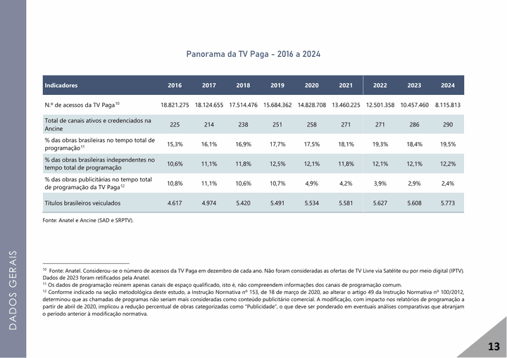

Source: [ANCINE, Anuário do Audiovisual Brasileiro 2024](https://www.gov.br/ancine/pt-br/oca/publicacoes/arquivos.pdf/anuario-do-audiovisual-brasileiro-2024-1.pdf), p.14

**This trajectory should feed through into rights pricing: Globo is likely to face growing pressure on the marginal rights it can profitably buy next cycle, while digital entrants appear to show rising willingness to pay.** The read-through: if the audience keeps migrating at current rates, the 2029 renegotiation could see a meaningful share shift from the traditional bundle (FTA + pay-TV + PPV) toward streaming and OTT, with corresponding implications for pricing power.

# Pillar #2 - Brazil vs Global Comparables

Annual broadcasting rights revenue by league (USD bn): NFL 10.4 … Brasileirão 0.4

[figure not shown]

Source: LFF / MATERIAL LIGA, p.6

Recurring revenue mix (broadcast / matchday / commercial): Brazil vs European leagues

[figure not shown]

Source: [Galápagos Outfield 2024](https://lp.galapagoscapital.com/relatorio_convocados), p.33

### Premier League - the benchmark and its plateau

**The Premier League’s 2025-29 cycle reached USD 16.48bn total (+17% vs prior), but the headline arguably masks two diverging dynamics.** Domestic grew only 2.3% annually (barely ahead of inflation), and per-match value declined 24% versus the 2016-19 peak. The real growth is international: now USD 8.74bn, exceeding domestic for the first time and up ~10x since 2007. The trajectory matters more than the scale. Founded on 20 February 1992 when the “Big Five” (Manchester United, Liverpool, Arsenal, Everton, Tottenham) led the break from the English Football League, the Premier League’s first deal, with Sky and the BBC, was worth £304mn over five years, then the largest in British sports history. Thirty-three years later it commands £6.7bn per cycle on domestic alone, a 22x nominal uplift (~10x real). This matters to Brazil for two reasons: i) it shows what a well-run, independent club-owned league can achieve when broadcasters compete properly; and ii) the largest gains come well after formation: Brazil today is analogous to England in 1995-2000, with the structural change in place but the financial gains still ahead.

### Ligue 1 - the cautionary tale

**Ligue 1 is the cautionary case for what happens when domestic broadcasters underperform.** The LFP targeted €1bn per season for 2024-2029 but no satisfactory bids materialized, salvaging a last-minute deal with DAZN (€400mn/year) and beIN Sports (€100mn/year), just €500mn per season. Compounding this, DAZN triggered an exit clause in 2025 citing disappointing subscriber numbers, paying a €100mn exit fee and leaving Ligue 1 without a primary domestic partner. This is the real-world embodiment of the “monetization lag” risk we flag below: a structural mismatch between rights ambitions and what single broadcasters can sustainably monetize. The architectural lesson is direct: Brazil’s multi-buyer structure distributes that risk across five buyers rather than concentrating it on one.

### MLS and IPL - the streaming-only and emerging-market benchmarks

**Major League Soccer signed a $2.5bn 10-year exclusive deal with Apple in 2022** (~$250mn/season), distributed entirely through Apple TV’s MLS Season Pass and eliminating traditional broadcast; in 2025 the parties revised terms to end the contract in 2029. For Brazil, MLS is the most relevant streaming-only case study: a smaller league by fan base and rights value, yet monetized through a single-platform streaming deal, conceptually similar to Amazon’s BRL 265mn Y1 deal with LFU, suggesting streaming-only models can scale further. The Indian Premier League is the fastest-growing major sports property globally, its domestic and international packages reaching ~$6.4bn in the current cycle, the second-most-valuable sports property in the world behind the NFL. For Brazil, IPL is the most relevant emerging-market benchmark: a non-European league in a developing economy that scaled to global top-tier rights values within a decade. IPL arguably shows what an emerging-market football league with proper distribution architecture could achieve over a 10-15 year horizon.

### Brazil - already at European Big 5 parity

**The combined Libra and LFU domestic deals reach ~BRL 2.87bn per year, ~EUR 470mn at current FX.** Against the comparables above, this places Brazil essentially at Ligue 1 levels (EUR 500mn/year, in distress after the DAZN exit) and on the same order of magnitude as Serie A a cycle ago; SportBusiness has flagged that Brazil could already qualify as the 5th-most-valuable domestic-rights football market globally. The framing has shifted: Brazil is no longer chasing the Big 5: it appears to have reached the lower end of that pack, and the question for 2029 is increasingly whether the market pushes it higher, rather than whether it can break in.

European league rights values and contract end dates, 2017/18-2028/29

[figure not shown]

Source: [Galápagos Outfield 2024](https://lp.galapagoscapital.com/relatorio_convocados), p.47

### Where the structural gap remains

**International rights monetization is the persistent gap.** The Brasileirão’s international rights generate close to zero today, versus USD 8.7bn for the Premier League. Even modest international monetization would add meaningful upside to the 2029 renegotiation envelope, and this stands out as among the most significant forward catalysts in the rest of this section.

Top-20 club valuation by market (USD bn): Europe 62.7 vs US 16.2 vs Brazil 8.2

[figure not shown]

Source: [Valuation TOP 30 Clubes (6th ed.)](https://www.sportsvalue.com.br/wp-content/uploads/2025/12/Valuation-TOP-30-clubes-6a.edicao.pdf), p.89

# Pillar #3 - Growth Vectors and Risks to 2029

**Looking ahead to the 2029 renegotiation, three vectors could materially expand the rights pool and two risks could compress it.** The vectors: i) international rights monetization, essentially zero today; ii) sports betting integration, newly regulated and reshaping advertising economics; and iii) further OTT competition if new global streamers (Netflix, Apple TV, DAZN, ByteDance) enter. The risks: i) audience fragmentation exceeding advertiser willingness to follow; and ii) CADE consolidation pressure, which has already barred new member additions during its investigation.

### Vector 1 - International rights

**The Brasileirão’s international rights generate essentially nothing today, which is part of why this stands out as among the largest forward levers.** Per recent media reports (ESPN, February 2025), Libra and LFU agreed to jointly negotiate international rights without Flamengo, the first time the two blocs cooperated on anything. The economic potential is meaningful given the multi-billion-dollar scale of comparable international pools (the Premier League captures USD 8.74bn per cycle), but the upside depends on negotiation outcomes not yet priced.

### Vector 2 - Sports betting integration

**Brazil legalized online sports betting in 2024, and operators (Bet365, Sportingbet, Estrela Bet, Esportes da Sorte, KTO) have rapidly become the largest advertisers in Brazilian football.** Per Galapagos, master sponsorship value across Série A clubs went from BRL 579mn in 2024 to BRL 988mn in 2025, a 70% uplift in a single year, largely driven by betting operators. Rights deals increasingly include betting-related inventory, with monetization still maturing.

### Vector 3 - New OTT entrants

**Current OTT participation (Amazon, CazéTV/YouTube, Record on FTA) is broad but not yet saturated.** Netflix is exploring sports rights globally; Apple TV has done MLS and MLB deals; DAZN is active in Europe and Latin America; ByteDance/TikTok could plausibly enter. Any of these joining the 2029 bidding would meaningfully expand the buyer pool and add pricing pressure.

### Risk 1 - Monetization lag (the Ligue 1 cautionary tale)

**Rapid audience migration could outpace advertiser/subscription monetization.** If audiences move to digital faster than monetization models catch up, the pool could compress as buyers retrench from over-paying. Ligue 1 is the real-world illustration: France targeted EUR 1bn/year for 2024-2029, settled for EUR 500mn, then saw DAZN exit mid-contract in 2025 after a EUR 100mn break fee. In our view, this is among the principal risks to the bull case, and one Brazil is not immune to if Premiere’s decline accelerates without commensurate growth from Amazon, CazéTV and other OTT entrants.

### Risk 2 - CADE regulatory pressure

**In late 2025, CADE barred new club additions to both blocs pending its anticompetitive-behavior investigation, and Libra paid a BRL 559k gun-jumping fine.** Looking ahead, if CADE eventually forces structural changes (for example, requiring unified single-bloc negotiation), the multi-buyer architecture could be partially undone, with uncertain implications for pricing power.

# Pillar #4 - Forward Outlook: Three Scenarios

### Base case - the trajectory continues

**Domestic rights uplift broadly in line with mature European leagues** (low-single-digit growth, modestly ahead of inflation). International rights begin to ramp but stay a fraction of domestic. Sports betting integration keeps expanding the commercial pool. No new OTT entrant materially shifts the bidding. The unified-league process consolidates seller leverage at the margin without fully replacing the current bloc structure.

### Bull case - multi-buyer competition accelerates

**A new OTT entrant (Netflix, Apple TV or equivalent) joins the bidding seriously.** International rights ramp meaningfully, capturing a non-trivial share of what comparable leagues realize globally. Sports betting becomes fully embedded as a rights monetization channel rather than sponsorship-only. The unified-league hypothesis materializes in time for the 2029 negotiation and consolidates the seller side against multiple buyers.

### Bear case - fragmentation persists, monetization stalls

**CADE forces restructuring back toward single-bloc negotiation or otherwise undoes the multi-buyer architecture.** Globo retrenches as the Premiere base compresses without a viable digital replacement. Amazon, Record or CazéTV reduce or do not renew at current levels. Sports betting regulation tightens. The unification process stalls.

### Implications for investment thesis

**The asymmetry appears to favor the bull case, though the risks are real and worth monitoring.** Even so, the base case alone should support a constructive narrative on Brazilian football rights, before any structural upside from international monetization and bloc consolidation. The next critical inflection is the 2029 renegotiation: the months immediately before (Q3-Q4 2028) are likely when the new architecture becomes visible, and the next 18 months look like a sensible window to position ahead of it. Overall, our highest-conviction angle is the distribution layer (LiveMode and adjacent platforms) rather than the league layer or the clubs: it i) captures the multi-buyer economics regardless of which buyer wins; ii) scales with audience migration rather than against it; and iii) is structurally more capital-efficient than owning rights or clubs.

# Sources - Compiled by Section and Pillar

## SECTION 1 - The Brazilian Football Broadcasting Rights Market

### Pillar #1 - From Unanimity to Fragmentation (1987-2020)

- [Lance, A história do Clube dos 13](https://www.lance.com.br/lancepedia/a-historia-do-clube-dos-13.html)
- [Trivela, Como surgiu o Clube dos 13](https://trivela.com.br/brasil/como-surgiu-o-clube-dos-13/)
- [Clube dos 13, Wikipedia EN](https://en.wikipedia.org/wiki/Clube_dos_13)
- [Lista de transmissoras do Brasileirão, Wikipedia](https://pt.wikipedia.org/wiki/Lista_de_transmissoras_do_Campeonato_Brasileiro_de_Futebol)
- [Peleja, Como o monopólio da Globo acabou (ou não)](https://peleja.com.br/comportamento/monopolio-globo-transmissoes-futebol-caze-ge-tv/)
- [Exame, Globo perde exclusividade sobre Brasileirão](https://exame.com/marketing/globo-perde-exclusividade-sobre-brasileirao/)
- [Sportico, Brazilian Soccer Broadcast Giant Fades as Super League Idea Rises](https://www.sportico.com/business/media/2022/brazilian-soccer-broadcast-giant-fades-super-league-rises-1234681733/)

### Pillar #2 - Regulatory Triggers (2020-2021)

- [Law 14,205/2021, full text (Planalto)](https://www.planalto.gov.br/ccivil_03/_ato2019-2022/2021/lei/l14205.htm)
- [Câmara dos Deputados, Lei 14,205 signing release](https://www.camara.leg.br/noticias/807872-nova-lei-garante-direito-de-transmissao-de-jogo-de-futebol-para-clube-mandante/)
- [Senado, Lei 14,205 signing release](https://www12.senado.leg.br/noticias/materias/2021/09/20/sancionada-lei-que-garante-direito-de-arena-ao-clube-mandante-em-transmissoes-de-futebol)
- [Câmara, MP 984 release](https://www.camara.leg.br/noticias/669802-medida-provisoria-da-direito-de-transmissao-de-jogos-para-clube-mandante)
- [Congresso Nacional, MPV 984/2020](https://www.congressonacional.leg.br/en/materias/medidas-provisorias/-/mpv/142594)
- [Olympics.com, Brasileirão 2025: Lei do Mandante explicada](https://www.olympics.com/pt/noticias/brasileirao-2025-lei-mandante-significado-libra-liga-forte-uniao)
- [Migalhas, Constitucionalidade do direito de arena MP 984](https://www.migalhas.com.br/depeso/329969/a-constitucionalidade-do-direito-de-arena-na-medida-provisoria-984-20)
- [Politize!, MP 984: o que é e seus efeitos](https://www.politize.com.br/mp-984-direitos-de-transmissao/)

### Pillar #3 - Libra and LFU: The Two Blocs

**Formation & current state**

**Diverging trajectory (LFU growing, Libra shrinking)**

- [Terra, LFU registra R$ 460M a mais em 2025](https://www.terra.com.br/esportes/corinthians/lfu-registra-r-460-milhoes-a-mais-em-2025-por-venda-dos-direitos-de-tv,74c5044255990caa08ba1b50dea09c6fcify76mx.html)
- [NetVasco, Disputa Libra x LFU termina com valores próximos](https://www.netvasco.com.br/n/354781/disputa-entre-libra-e-lfu-termina-com-valores-proximos-veja-quanto-blocos-vao-faturar-com-tv)

**Institutional capital & transaction comparables**

- [Neofeed, BTG vs XP no duelo bilionário do futebol](https://neofeed.com.br/negocios/no-futebol-o-novo-e-bilionario-duelo-entre-btg-e-xp/)
- [Máquina do Esporte, LFU conclui venda de direitos comerciais](https://maquinadoesporte.com.br/futebol/com-novo-investidor-liga-forte-futebol-conclui-contrato-de-venda-de-direitos-comerciais/)

**Mubadala-Libra discussions**

- [Lance, Nova agência e garantia de R$ 1,4 bi: nova proposta Mubadala](https://www.lance.com.br/lancebiz/mercado-do-esporte/nova-agencia-e-garantia-de-r-14-bilhao-aos-clubes-entenda-a-nova-proposta-do-mubadala-a-libra.html)
- [Máquina do Esporte, Mubadala propõe R$ 4 bi à Libra](https://maquinadoesporte.com.br/futebol/mubadala-propoe-pagamento-de-r-4-bilhoes-a-libra-se-houver-adesao-de-ao-menos-18-times/)
- [Máquina do Esporte, Libra próxima de acerto com Mubadala](https://maquinadoesporte.com.br/futebol/libra-fica-proxima-de-acerto-apos-nova-proposta-do-mubadala/)

**Realignments & the Flamengo dispute**

- [Neofeed, Atlético-MG vai para LFU; pode esvaziar Libra](https://neofeed.com.br/negocios/exclusivo-atletico-mineiro-vai-para-a-liga-forte-uniao-e-pode-puxar-a-fila-para-esvaziar-a-libra/)
- [CNN Brasil, Palmeiras anuncia saída da Libra](https://www.cnnbrasil.com.br/esportes/futebol/palmeiras/apos-acordo-do-flamengo-com-a-libra-palmeiras-anuncia-saida-do-bloco/)
- [Terra, Corinthians, Palmeiras e Flamengo não assinam liga](https://www.terra.com.br/esportes/futebol/corinthians-palmeiras-e-flamengo-nao-assinam-documento-para-criacao-de-liga-brasileira-entenda,87ae63d349924b48f3c17e3ab8e3962e2o2yvj18.html)
- [Futebol na Web, Acordo histórico Flamengo-Libra](https://futebolnaweb.com.br/times/flamengo/acordo-historico-flamengo-clubes-libra-direitos-transmissao/)
- [Mixvale, Atlético-MG sai da Libra e volta para LFU](https://www.mixvale.com.br/2025/10/28/atletico-mg-sai-da-libra-e-volta-a-liga-forte-uniao-para-buscar-equilibrio-nos-direitos-de-tv-do-brasileirao/)
- [95 FM, Libra acordo Flamengo, ganho R$ 150 mn](https://www.95fmoficial.com.br/noticia/clubes-da-libra-chegam-a-acordo-sobre-divisao-de-receitas-e-flamengo-tera-ganho-adicional-de-r-150-milhoes-ate-2029)

**CADE oversight**

- [Brasil 247, CADE chancela acordos com ligas e impõe regras](https://www.brasil247.com/brasil/cade-chancela-acordos-com-ligas-do-futebol-e-impoe-regras-para-evitar-irregularidades)
- [IstoÉ Dinheiro, CADE barra adesão de novos clubes](https://istoedinheiro.com.br/cade-barra-adesao-de-novos-clubes-pela-libra-e-liga-forte-uniao-para-investigar-tentativa-de-monopolio-nas-transmissoes-de-futebol)
- [Portal Leo Dias, Decisão CADE impacta Atlético-MG na LFU](https://portalleodias.com/esportes/entenda-como-a-decisao-do-cade-impacta-entrada-do-atletico-mg-na-lfu)
- [Bahia Notícias, CADE impede Libra e LFU de admitir novos clubes](https://www.bahianoticias.com.br/esportes/noticia/76342-cade-impede-libra-e-liga-forte-uniao-de-admitir-novos-clubes-durante-investigacao-sobre-concorrencia)
- [Lance, Cade pode anular atos de Libra e LFU](https://www.lance.com.br/futebol-nacional/cade-pode-anular-atos-de-libra-e-lfu-e-unificacao-de-ligas-fica-mais-distante.html)
- [Máquina do Esporte, Clubes peitam Flamengo; distribuição pode ir à Justiça](https://maquinadoesporte.com.br/futebol/clubes-peitam-flamengo-e-distribuicao-de-receita-da-libra-pode-ir-a-justica/)

**The SAF revolution, Law 14,193/2021 and club corporatization**

- [ISTOÉ Dinheiro, Futebol brasileiro acumula 42 SAFs; lista e modelos](https://istoedinheiro.com.br/futebol-brasileiro-ja-acumula-42-safs-veja-lista-e-diferentes-modelos-de-negocio)
- [Economic News Brasil, Ceará, Botafogo e Atlético expõem crise das SAFs](https://economicnewsbrasil.com.br/2026/05/10/safs-endividadas-no-brasil-crise-financeira-clubes/)
- [ADVFN, Histórico das SAF no Brasil: valores e investidores](https://br.advfn.com/jornal/2025/09/historico-das-saf-no-brasil-valores-investidores-e-como-a-proposta-do-fluminense-se-compara)
- [Estado de Minas, O que é SAF? Entenda o modelo de negócio](https://www.em.com.br/trends/2026/03/7369105-o-que-e-saf-entenda-o-modelo-de-negocio-que-tem-mudado-o-futebol.html)

### Pillar #4 - Toward a Single League (Unification)

- [CNN Brasil, Libra e LFU avançam para unificação, trocam documentos e estimam prazo](https://www.cnnbrasil.com.br/esportes/futebol/libra-e-lfu-avancam-para-unificacao-trocam-documentos-e-estimam-prazo/)
- [Itatiaia, Libra e LFU avançam para unificação](https://www.itatiaia.com.br/esportes/futebol/futebol-nacional/libra-e-lfu-avancam-para-unificacao-trocam-documentos-e-estimam-prazo)
- [Itatiaia, Dirigente da LFU avalia unificação e fair play financeiro](https://www.itatiaia.com.br/esportes/futebol/futebol-nacional/dirigente-da-lfu-avalia-unificacao-de-ligas-e-faz-apelo-por-fair-play-financeiro)
- [Mkt Esportivo, CBF propõe liga única no Brasil (abril 2026)](https://www.mktesportivo.com/2026/04/cbf-propoe-liga-unica-no-brasil-e-quer-atuar-como-mediadora-e-responsavel-pelo-futebol-nacional/)
- [Diário do Nordeste, CBF convoca clubes Libra e FFU para unificar ligas](https://diariodonordeste.verdesmares.com.br/jogada/cbf-convoca-clubes-da-libra-e-da-ffu-para-unificar-ligas-1.3755294)
- [O Tempo, CBF chama clubes Libra e FFU e quer unificar ligas](https://www.otempo.com.br/sports/futebol-nacional/2026/4/6/cbf-chama-clubes-da-libra-e-da-ffu-e-quer-unificar-ligas)
- [ESPN, CBF inicia processo de unificação e visa liga única 2030](https://www.espn.com.br/futebol/brasileirao/artigo/_/id/16537433/cbf-inicia-processo-unificacao-visa-liga-unica-gerir-series-a-b-brasileiro-partir-2030-veja-bastidores)
- [ESPN, Fair play financeiro e gramado como “temas sensíveis”](https://www.espn.com.br/futebol/artigo/_/id/14938342/brasileirao-liga-fair-play-financeiro-gramado-temas-sensiveis-uniao-libra-lfu)
- [Jovem Pan, Liga Unificada de Clubes 2027](https://jovempan.com.br/opiniao-jovem-pan/comentaristas/wanderley-nogueira-comentaristas/liga-unificada-de-clubes-cbf-tenta-unificar-o-futebol-brasileiro-em-2027.html)
- [PortalGO, CBF estuda liga nos moldes da Premier League](https://portalgo.com.br/esportes/cbf-estuda-liga-nos-moldes-da-premier-league)
- [The Playoffs, Brasileirão sem a CBF? Libra e LFU avançam](https://theplayoffs.news/noticias/brasileirao/brasileirao-sem-a-cbf-libra-e-lfu-avancam-em-negociacao-para-organizar-a-competicao/)
- [Lance, Libra e FFU: quais clubes em cada liga em 2026](https://www.lance.com.br/lancebiz/libra-e-ffu-quais-sao-os-clubes-de-cada-liga-do-brasileirao-2026-veja-divisao.html)
- [Meutimao, CBF propõe união para clubes da Libra e LFU](https://www.meutimao.com.br/noticias-do-corinthians/530497/cbf-propoe-uniao-para-clubes-da-libra-e-lfu-por-criacao-de-liga-unica-no-futebol-brasileiro)
- [Imirante, Clubes defendem Liga Única com CBF](https://m.imirante.com/esporte/brasil/2026/03/20/clubes-defendem-liga-unica-com-cbf-no-futebol-brasileiro)
- [Fut1, Liga Única do Futebol Brasileiro: FFU e Libra se aproximam](https://www.fut1.com.br/2026/03/liga-unica-futebol-brasileiro-ffu-libra-cbf.html)
- [Fut1, CBF Assume o Comando e Muda as Regras do Jogo](https://www.fut1.com.br/2026/03/liga-unica-futebol-brasileiro-cbf.html)

### Pillar #5 - Contract Architecture (2025-2029)

- [Lance, Direitos de TV definidos: disputa Libra x LFU](https://www.lance.com.br/lancebiz/direitos-de-transmissao-definidos-libra-x-lfu-no-faturamento-com-brasileirao.html)
- [Lance, Prime Video assina contrato com LFU](https://www.lance.com.br/lancebiz/prime-video-fecha-contrato-com-lfu-para-transmissao-do-brasileirao-2025.html)
- [Terra, Globo fecha acordo e LFU alcança R$ 1,7 bi](https://www.terra.com.br/esportes/futebol/globo-fecha-acordo-para-exibir-brasileirao-e-lfu-alcanca-r-17-bilhao-com-todos-pacotes,c5df63d07c926b878841f371ad2162d85aqtpst3.html)
- [Terra, Record compra direitos do Brasileirão](https://www.terra.com.br/esportes/futebol/record-compra-direitos-e-transmitira-o-brasileirao-a-partir-de-2025,3150c0e5ebcee6b2a30761710d733058y2esxsrj.html)
- [Terra, Mubadala envia oferta pela Libra](https://www.terra.com.br/esportes/futebol/mubadala-envia-oferta-pela-libra-com-receita-garantida-maior-que-r-1-bilhao,313354ce25d47248376280293c117bf1l4tpkd87.html)
- [Terra, Amazon Prime Video anuncia Brasileirão 2025](https://www.terra.com.br/esportes/futebol/amazon-prime-video-anuncia-exibicao-do-campeonato-brasileiro-2025,0fe140f9ad52a5c902b3f2f428c4a5ce11e2wp43.html)
- [Cassio Zirpoli, Brasileirão 2026 transmissão definida (10+10)](https://cassiozirpoli.com.br/definida-a-transmissao-do-brasileirao-2026-com-10-times-da-libra-e-10-times-da-lfu/)
- [RD1, Quantos bilhões a Globo gastou em Libra e LFU](https://rd1.com.br/quantos-bilhoes-a-globo-gastou-para-transmitir-libra-e-lfu-no-brasileirao-2025/)
- [Le Monde Diplomatique BR, Direitos de transmissão em 2025](https://diplomatique.org.br/como-os-direitos-de-transmissao-dessas-competicoes-estao-em-2025/)
- [Trivela, Brasileirão: divisão dos direitos a partir de 2025](https://trivela.com.br/brasil/campeonato-brasileiro/brasileirao-2025-divisao-direitos-transmissao-tv/)
- [Olympics.com, Brasileirão 2025: onde assistir](https://www.olympics.com/pt/noticias/brasileirao-2025-onde-assistir-transmissao)
- [Goal, Como CazéTV e YouTube conseguiram comprar direitos do Brasileirão](https://www.goal.com/br/listas/como-cazetv-youtube-conseguiram-comprar-direitos-brasileirao-liga-forte-uniao/bltc82e0553fb76ec28)
- [SportBusiness, Brasileirão domestic media rights: a tale of two halves](https://media.sportbusiness.com/2025/02/brasileirao-domestic-media-rights-a-tale-of-two-halves/)
- [Sportcal, Globo and ESPN keep Copa Libertadores rights until 2030](https://www.sportcal.com/news/globo-and-espn-keep-copa-libertadores-and-sudamericana-rights-until-2030/)
- [Máquina do Esporte, LFU estende contrato Record + CazéTV até 2029](https://maquinadoesporte.com.br/midia/lfu-estende-contrato-de-direitos-de-tv-do-brasileirao-com-record-e-cazetv-ate-2029/)
- [Máquina do Esporte, Amazon Prime confirma transmissão 2025-2029](https://maquinadoesporte.com.br/midia/amazon-prime-video-confirma-transimssao-de-brasileirao-2025-com-pacote-da-lfu/)
- [Tecmundo, Amazon Prime compra direitos do Brasileirão](https://www.tecmundo.com.br/mercado/294696-amazon-prime-video-compra-direitos-transmissao-jogos-brasileirao.htm)
- [TAVI, Amazon Prime Brasileirão exclusive rights](https://tavilatam.com/en/brazil-amazon-prime-video-acquires-exclusive-rights-package-to-broadcast-brasileirao-matches-live/)
- [Meio & Mensagem, Valor do futebol para empresas de mídia 2025](https://www.meioemensagem.com.br/midia/futebol-na-midia-veja-o-valor-das-cotas-de-tv-em-2025)
- [Brazilian Football, Brasileirão Broadcast Partnerships](https://www.brazilian-football.com/brasileirao-broadcast-partnerships-elevating-the-viewing-experience/)

**Globo’s strategic response (sub-section within Pillar #5)**

- [CNN Brasil, Globo muda estratégia para enfrentar CazéTV](https://www.cnnbrasil.com.br/economia/macroeconomia/globo-muda-estrategia-para-enfrentar-cazetv-e-acirra-streaming-esportivo/)
- [SportBusiness, Globo out as quartet land Brasileiro Série B rights](https://www.sportbusiness.com/news/globo-out-as-quartet-land-brasileiro-serie-b-rights/)

### Pillar #6 - Revenue Distribution

- [Lance, Divisão de receitas da Libra: critérios](https://www.lance.com.br/lancebiz/divisao-de-receitas-da-libra-entenda-calculos-conceitos-e-novos-criterios-do-bloco.html)
- [Lance, Brasileirão 2025: desigualdade entre clubes](https://www.lance.com.br/brasileirao/brasileirao-2025-novo-modelo-de-venda-de-direitos-de-transmissao-pode-gerar-desigualdade-entre-clubes.html)
- [Itatiaia, Libra e LFU: divisão e valores 2025](https://www.itatiaia.com.br/esportes/futebol/brasileiro-serie-a/2024/12/09/libra-e-lfu-veja-divisao-de-clubes-e-valores-para-o-brasileirao-2025)
- [Um Dois Esportes, Brasileirão 2025: quanto cada clube receberá](https://www.umdoisesportes.com.br/campeonatos/brasileirao/brasileirao-2025-quanto-cada-clube-recebera-premiacao/)

## SECTION 2 - LiveMode: A Case Study in Sports Rights Distribution

### Pillar #1 - Origin (from Esporte Interativo to LiveMode)

- [LiveMode, site institucional](https://www.livemode.com/)
- [LiveMode, Wikipedia (PT)](https://pt.wikipedia.org/wiki/LiveMode)
- [LiveMode, LinkedIn](https://br.linkedin.com/company/livemode)
- [Times Brasil/CNBC, LiveMode: quem é a empresa dona da CazéTV](https://timesbrasil.com.br/entretenimento/livemode-quem-e-a-empresa-dona-da-cazetv/)
- [Tela Viva, LiveMode busca atender demanda esportiva digital](https://telaviva.com.br/20/08/2024/livemode-busca-atender-a-crescente-demanda-das-entidades-esportivas-no-ambiente-digital/)
- [SportBusiness Media, LiveMode profile](https://media.sportbusiness.com/organization/livemode/)

### Pillar #2 - Business Model

(largely covered by Pillar #1 sources plus the rights portfolio in Pillar #5)

### Pillar #3 - CazéTV: from partnership to 100% acquisition

- [Lance, LiveMode compra 100% da CazéTV; Casimiro vira sócio global](https://www.lance.com.br/lancebiz/livemode-compra-100-da-cazetv-e-casimiro-se-torna-socio-de-marca-global-do-grupo.html)
- [InvestNews, LiveMode assume 100% da CazéTV (exclusivo)](https://investnews.com.br/negocios/live-mode-assume-100-cazetv/)
- [Terra, Casimiro vende ações da CazéTV](https://www.terra.com.br/esportes/futebol/casimiro-vende-acoes-da-cazetv-e-vira-socio-de-holding-mundial,30b9503d1bdd763a6bac25052f24b8a1lqdj3efu.html)
- [Mkt Esportivo, Casimiro transfere participação da CazéTV](https://www.mktesportivo.com/2025/11/casimiro-transfere-participacao-da-cazetv-e-entra-na-holding-internacional-da-livemode/)
- [Pipoca Moderna, Casimiro vende participação CazéTV](https://pipocamoderna.com.br/2025/11/casimiro-miguel-vende-participacao-cazetv-livemode-sociedade/)
- [Áreavip, Casimiro vende a CazéTV](https://www.areavip.com.br/televisao/casimiro-miguel-vende-a-cazetv-sucesso-do-streaming-esportivo-brasileiro/)
- [Meio & Mensagem, Audiência Olímpica: recordes de Globo e CazéTV](https://www.meioemensagem.com.br/olimpiadas/audiencia-olimpica-os-recordes-de-globo-e-cazetv)
- [Streams Charts, Paris 2024 Summer Olympics Livestreaming](https://streamscharts.com/news/2024-paris-summer-olympics-livestreaming-results)
- [TechTudo, Como assistir Olimpíadas 2024 na CazéTV](https://www.techtudo.com.br/dicas-e-tutoriais/2024/07/como-assistir-as-olimpiadas-2024-ao-vivo-e-de-graca-na-cazetv-esports.ghtml)

### Pillar #4 - Institutional Capital and Shareholders

- [General Atlantic, Strategic Minority Investment in LiveMode (official release)](https://www.generalatlantic.com/media-article/general-atlantic-and-xp-announce-strategic-minority-investment-in-brazil-based-livemode/)
- [Brazil Journal, General Atlantic e XP compram fatia da LiveMode](https://braziljournal.com/general-atlantic-e-xp-compram-fatia-da-livemode-dona-da-cazetv/)
- [Bloomberg Línea, General Atlantic e XP aporte na LiveMode](https://www.bloomberglinea.com.br/negocios/general-atlantic-e-xp-fazem-aporte-na-livemode-de-marketing-esportivo/)
- [Máquina do Esporte, Investidoras da LFU compram parte da LiveMode](https://maquinadoesporte.com.br/midia/investidoras-de-lfu-general-atlantic-e-xp-compram-parte-da-livemode-que-negocia-direitos-da-liga/)
- [Sportcal, General Atlantic and XP strategically invest in LiveMode](https://www.sportcal.com/media/general-atlantic-and-xp-strategically-invest-in-livemode/)
- [SportBusiness, LiveMode takes on investment from LFU project partners](https://www.sportbusiness.com/news/livemode-takes-on-investment-from-lfu-project-partners-general-atlantic-xp/)
- [LiveMode, PitchBook profile](https://pitchbook.com/profiles/company/549963-64)
- [LiveMode, Crunchbase](https://www.crunchbase.com/organization/livemode)
- [CNN Brasil, Cristiano Ronaldo vira acionista da LiveMode](https://www.cnnbrasil.com.br/esportes/futebol/futebol-internacional/cristiano-ronaldo-vira-acionista-da-livemode-dona-da-cazetv/)
- [Lance, Cristiano Ronaldo vira sócio da LiveModeTV](https://www.lance.com.br/lance-negocios/cristiano-ronaldo-compra-acoes-de-dona-da-caze-tv-e-se-torna-parceiro-da-empresa.html)
- [Meio & Mensagem, Os planos da LiveMode para seu fundo de investimentos](https://www.meioemensagem.com.br/midia/os-planos-da-livemode-para-seu-fundo-de-investimentos)

### Pillar #5 - Rights Portfolio (FIFA, LFU, Olympics)

- [FIFA, CazéTV agreement strengthens World Cup 26 coverage in Brazil](https://inside.fifa.com/news/cazetv-agreement-strengthens-world-cup-26-coverage-in-brazil)
- [SportBusiness, LiveMode’s FIFA love affair continues with 2026 World Cup mandate](https://www.sportbusiness.com/news/livemodes-fifa-love-affair-continues-with-2026-world-cup-sales-mandate/)
- [Sportcal, LiveMode and FIFA extend World Cup media rights partnership](https://www.sportcal.com/media/livemode-and-fifa-extend-world-cup-media-rights-sales-partnership/)
- [Sportcal, CazéTV to cover all 104 FIFA World Cup games in 2026](https://www.sportcal.com/media/cazetv-to-cover-all-104-fifa-world-cup-games-in-2026/)
- [2026 FIFA World Cup broadcasting rights, Wikipedia](https://en.wikipedia.org/wiki/2026_FIFA_World_Cup_broadcasting_rights)
- [Goal, Todos campeonatos e direitos de transmissão da CazéTV](https://www.goal.com/br/listas/todos-campeonatos-direitos-transmissao-da-cazetv/bltf6802c4e1ae9efdd)

### Pillar #6 - International Ambition

- [InvestNews, General Atlantic aposta no futebol mexicano](https://investnews.com.br/negocios/general-atlantic-mexico-america/)

## SECTION 3 - Sizing the Market

### Pillar #1 - The 2025 Baseline

- [CBF Portal de Governança, Demonstrações Financeiras](https://portaldegovernanca.cbf.com.br/balanco-anual-cbf)
- [CBF, Receita recorde 2024](https://www.cbf.com.br/a-cbf/noticias/informes/a/cbf-registra-receita-recorde-e-pela-primeira-vez-mais-de-r-1-bilhao-investido-no-futebol-em-2024)
- [Máquina do Esporte, CBF apresenta balanço com receita R$ 1,5 bi 2024](https://maquinadoesporte.com.br/futebol/cbf-apresenta-balanco-as-federacoes-com-receita-de-r-15-bilhao-em-2024/)
- [Sports Value, Valuation TOP 30 clubes Brasil 2025 (PDF)](https://www.sportsvalue.com.br/wp-content/uploads/2025/12/Valuation-TOP-30-clubes-6a.edicao.pdf)
- [Sports Value, Finanças TOP 20 clubes brasileiros 2024 (PDF)](https://www.sportsvalue.com.br/wp-content/uploads/2025/05/Financas-clubes-2024-Final-report-maio-2025.pdf)
- [Galapagos, Relatório Convocados 2025](https://lp.galapagoscapital.com/relatorio_convocados)
- [Lance, Ranking Pluri 2024: Palmeiras e Flamengo lideram](https://www.lance.com.br/lancebiz/mercado-do-esporte/ranking-pluri-2024-palmeiras-e-flamengo-lideram-com-folga-veja-posicao-do-seu-time.html)
- [Pluri Sports, Relatórios por clube](https://www.plurisports.com.br/relatorio-home/)
- [ESPN, De onde vem o dinheiro da CBF](https://www.espn.com.br/futebol/artigo/_/id/15227764/de-onde-vem-dinheiro-cbf-como-entidade-fatura-alto-r-2-bilhoes-caixa)
- [ESPN, Flamengo oficializa faturamento R$ 2 bi 2025](https://www.espn.com.br/futebol/flamengo/artigo/_/id/16116791/flamengo-oficializa-faturamento-2-bilhoes-faz-historia-futebol-brasileiro)
- [CNN Brasil, Flamengo balanço 2025 R$ 2 bi](https://www.cnnbrasil.com.br/esportes/futebol/flamengo/flamengo-divulga-balanco-de-2025-com-receita-recorde-de-r-2-bilhoes-veja/)
- [Exame, Flamengo é o clube mais valioso do Brasil em 2025](https://exame.com/esporte/flamengo-e-o-clube-mais-valioso-do-brasil-em-2025-veja-ranking-2/)
- [Statista, Sports Brazil Market Forecast](https://www.statista.com/outlook/amo/sports/brazil)
- [GlobalData, Brazil Sports Broadcasting Media Market](https://www.globaldata.com/store/report/brazil-sports-broadcasting-media-market-analysis/)
- [GIIResearch, Brazil Sports Broadcasting Media Landscape](https://www.giiresearch.com/report/gd1388227-brazil-sports-broadcasting-media-television.html)

### Pillar #2 - Audience Trajectory (cord-cutting, OTT)

- [ANCINE, Anuário do Audiovisual Brasileiro 2024 (PDF)](https://www.gov.br/ancine/pt-br/oca/publicacoes/arquivos.pdf/anuario-do-audiovisual-brasileiro-2024-1.pdf)
- [ANCINE, Informe Trimestral TV Paga jan-jun 2024 (PDF)](https://www.gov.br/ancine/pt-br/oca/televisao/conteudos/informe-trimestral-de-tv-paga-jan-jun-2024.pdf)
- [Ken Research, Brazil OTT Sports Streaming Market 2019-2030](https://www.kenresearch.com/brazil-ott-sports-streaming-platforms-market)
- [Ken Research, Brazil OTT Sports and Streaming Media Market](https://www.kenresearch.com/brazil-ott-sports-and-streaming-media-market)

### Pillar #3 - Brazil vs Global Comparables (Premier League, La Liga)

- [Arthnova, Premier League Broadcast Rights: £12B Deal (2025-29)](https://arthnova.com/premier-league-broadcast-rights-economics-12-billion/)
- [Match Day Finance, Premier League Broadcast Deals 2025/26 to 2028/29](https://www.matchdayfinance.com/post/premier-league-broadcast-deals-2025-26-to-2028-29)
- [InsiderSport, La Liga deal close Premier League gap](https://insidersport.com/2025/12/01/la-liga-deal-close-premier-league-gap/)
- [The ESK, Analysis Series: English and Major European Football Broadcast Rights Market](https://theesk.org/2025/08/15/the-analysis-series-the-english-and-major-european-football-broadcast-rights-market/)
- [Tifosy, Broadcasting breakdown: the European Big 5](https://www.tifosy.com/en/insights/broadcasting-breakdown-the-european-big-5-3481)
- [Daniel Geey, Football Broadcasting Deals Across the Top 5 European Leagues](https://www.danielgeey.com/done-deal-blog/football-broadcasting-deals-across-the-top-5-european-leagues)
- [SportBusiness, Premier League Media Rights 2001-2022](https://www.sportbusiness.com/premier-league-media-rights-2001-2022/)
- [Deloitte Football Money League 2025](https://www.deloitte.com/global/en/Industries/tmt/analysis/deloitte-football-money-league.html)
- [Foundation of the Premier League, Wikipedia](https://en.wikipedia.org/wiki/Foundation_of_the_Premier_League)

### Pillar #4 - Growth Vectors and Risks

- [ESPN, Libra e LFU se unem em venda de direitos internacionais (sem Flamengo)](https://www.espn.com.br/futebol/brasileirao/artigo/_/id/15412943/sem-flamengo-acordo-libra-lfu-unem-venda-direitos-transmissao-internacional-brasileirao)
- [Ken Research, Global Sports Media Market 2019-2030](https://www.kenresearch.com/global-sports-media-market)
- [Grand View Research, Sports Broadcasting Technology Market 2030](https://www.grandviewresearch.com/industry-analysis/sports-broadcasting-technology-market-report)

### Pillar #5 - Forward Sizing Scenarios

(cenários construídos a partir das fontes acima, sem refs adicionais específicas)

## Cross-cutting & General References

Materials que informam múltiplos pilares ou servem de pano de fundo conceitual:

- [FGV, Caderno Futebol e Desenvolvimento Socioeconômico (PDF)](https://bibliotecadigital.fgv.br/dspace/bitstream/handle/10438/11316/fgvprojetos_caderno_futebol.pdf?isAllowed=y&sequence=5)
- [FGV, A Evolução da Gestão no Futebol Brasileiro](https://repositorio.fgv.br/server/api/core/bitstreams/e8eb75a2-acff-4e9e-9362-713060841093/content)
- [SciELO, Entendendo o futebol como um negócio](http://www.scielo.br/j/gp/a/kM9tcDvCHmxQw7XYwXnk3Yq/?lang=pt)
- [SciELO, A mercantilização do futebol brasileiro](https://www.scielo.br/j/cebape/a/XmxfDtmDMKgKt9M5LzL7KDj/?lang=pt)
- [Campeonato Brasileiro Série A, Wikipedia](https://en.wikipedia.org/wiki/Campeonato_Brasileiro_S%C3%A9rie_A)